# Exploring significant predictors for decision of taking PrEP among high-risk population

Weilu Song

### Overview

To better control HIV infection among high risk population, it urgently needs to explore the relationship between related determinants that may affect Pre-Exposure Prophylaxis (PrEP) usage. Jilinde PrEP cohort study was conducted in Kenya, it contains over 1000 participants and 300 variables that are related to PrEP usage among high risk population. In this project, curated dataset is used to analyze the potential PrEP predictors that can be used as precidor for decision of taking PrEP among targeted population.

The original files of this final project can be accessed from here: [Final project_Song](https://github.com/aaronwlsong/BMIN503_Final_Project)

### Introduction

Pre-Exposure Prophylaxis (PrEP) has been proven an effective way to prevent HIV infection.[1] However, the PrEP coverage among high risk population is still low.[2] The reason behind it is complex, because making a behavioral decision such as initiate PrEP is determined by multiple factors such as social determinants, self-perception, and clinical history. To better curb HIV infection among high risk population, it is urgent to identify the key factors that may affect the decision of taking PrEP. Because that will tremendously helps both researcher and local policy makers to advocate PrEP as a main HIV prevention strategy in Kenya.  
As aforementioned, because the factors that may influence the decision of taking PrEP are interdisciplinary, when conduct and collect the dataset, the researchers always try to capture as many participant’s characteristics as possible. Therefore, it leads a fact that a typical epidemiological dataset usually contains over 100 or sometimes couple hundreds variables. Sometimes, those variables are highly collinearity.As it is proved by previous studies, a precise predictive result is highly depended on model and variable selection, which means that once the outcome is settled, the main challenges for researchers are how to find the significant associated predictors related to outcome and establish the best predictive model to answer the hypothesis they posed.  
In recent decade, machine learning method has been widely applied in more and more fields, it also shapes the way how to establish a predictive model in the field of public health.[3] Compared to the traditional way which the variables/predictors selection was heavily relied on the researcher’s background knowledge and literature review, and then pick up the appropriated variables from dataset for model they use, using machine learning algorithm not only helps researchers to quickly pick up the most significant associated variables among the hundreds variables, but also enables them to optimize the model based on the rough result, and optimize the model till it is satisfied.[4][5]  
In this study, we use this JILINDE cohort study, but only the baseline completed dataset to explore the significant predictor for decision of taking PrEP. By applying the dataset into multiple supervised machine learning models, we expect to compare and evaluate the best performance model for this dataset, and further optimize the selected model. It is expected to through this research, we can provide a references for HIV prevention through PrEP in local area. In addition, we also want to present model optimization method by integrating causal inferential theory to machine learning model.

##### Hypothsis

In this research, the **primary aim** is exploring significant predictors for outcome: Decision of taking PrEP (original variable name: agree_prep). And the **secondary aim** is comparing machine learning model’s performances given a imbalanced dataset. Specifically, we will compare different machine learning algorithms and the different performance between original selected model and optimized model.

### Methods

Given the consideration of workload of missing data imputation, complication of analysis of repeated measure dataset and etc, in this project, we curate the dataset by only using the baseline data for the final analysis. In addition, in data cleaning process, instead of imputing the missing data, we remove the observations with missing data, using the completed dataset for analysis.  
**Step 1: Outcome variable inspection** Fist, we pick up a outcome variable based on primary study hypothesis. The outcome variable is agree_prep, which has the definition of whether agree to take PrEP. barplot is used to inspect the outcome variable, to see whether it has balanced outcomes across yes and no group.  
**Step 2: Demographic variable inspection** Second, we use the map tool,barplot and violin plot to explore the single relationship between each demographic variable and outcome. For example, map tool shows the distribution of study sites given the gross income and age in Kenya. Then the Table 1 is used to present the overall results.  
**Step 3: Variable selection** Third, Then we used variables (other than outcome vairiable) as predictors to find the statistical significant predictors that are related to outcome at $\alpha$=0.05 level. This process is firstly used GLM model, and then use the random forest tree to replicate the process and collect top significant predictors based on the Gini score result. We list the Gini score result from the RF and P-value from GLM side by side to highlighted how many variables are overlapped in these two methods.  
**Step 4: Model evaluation** Fourth, because of imbalanced dataset we used in this research, to compare and choose the best model to handle this type of dataset, we compare 3 machine learning models: SVM, Random forest tree and GLM, then use k-cross validation (k=10), ROC curve and AUC to evaluate each model’s performance.

**Step 5: Create original GLM model**  
1) The original GLM model. The original model will be use the top 6 statistical significant variables/predictors that are selected by GLM, meanwhile, these 6 variables must be also showed in Gini score result.

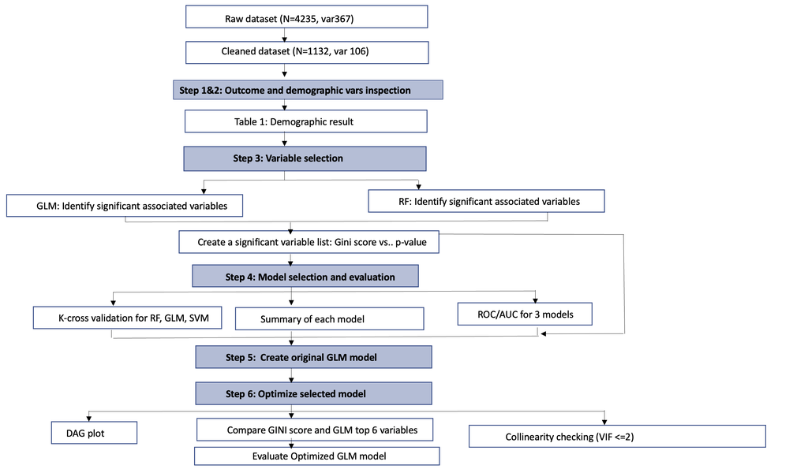

Figure 1. Flowchart of research method

#### 1. Data preparation

```r
pacman::p_load(rio,here,skimr,tidyverse,dplyr,haven,codebook,knitr,BiocManager,rlist,tools,qdapTools,janitor,fastDummies,labelled,magrittr,plyr,readxl,data.table,purrr,stringr,readxl,tidyr,dplyr,fastDummies,questionr,sqldf, fs, kableExtra, lubridate, mise,mice, VIM,mitools, sjmisc,randomForest,pROC,PRROC,glmnet, factoextra, ggdendro, Rtsen,devtools,e1071,GEOS,gtsummary,dagitty,lavaan)
library(devtools)
install_github("vqv/ggbiplot")
```

##### 1-1 Data loading and cleaning

```r
#rm(list=ls())
# Retreive baseline data from cohort study
df503<-rio::import(here::here("rawdata","jilinde_coh_2022aug.csv"))%>%
  dplyr::filter(event_name=="Baseline")

# Remove the missing value and only one unique value.
dfcheck<-skimr::skim(df503)%>%
  tibble::as.tibble()%>%
  dplyr::filter(character.empty==0)%>% # Keep completed case
  dplyr::filter(character.n_unique >1) #Remove only one level factor

#Convert categorical variables as factor and derived age group: agegrp based on continuous var: age
fdat<-df503%>%
   dplyr::select(dfcheck$skim_variable, agree_prep, age)%>%
   dplyr::mutate(age=as.numeric(age),
          agegrp=dplyr::case_when(age<25|age==25~"Young",
                                   age>25~"Adult",))%>%
   dplyr::filter(agree_prep!="")%>% #Remove the null value in outcome
   dplyr::select(everything(), -c(age,data_access_group, record_id, record_create_date))%>%
   dplyr::mutate_each_(dplyr::funs(factor(.)),names(dfcheck$skim_variable)) #remove unused variable

cols<-names(fdat)[!(names(fdat) %in% c("age"))]
 fdat<-fdat%>%dplyr::mutate_each_(dplyr::funs(factor(.)),cols) #convert to factors

#str(fdat)
table(fdat$agree_prep)
```

```
##
##   No  Yes
##   24 1108
```

```r
#colSums(is.na(fdat))
```

#### 2. Dependent/outcome variable inspection

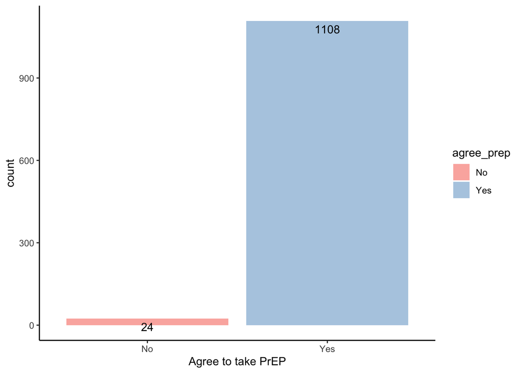

```r
ggplot(fdat, aes(factor(agree_prep), fill= agree_prep))+
  geom_bar()+
  xlab("Agree to take PrEP")+
  geom_text( stat = "count", aes(label = ..count..), vjust = 1.5, colour = "black")+
  scale_fill_brewer(palette = "Pastel1")+
  theme_classic()
```

As we can see from the bar plot, in this dataset, the outcome for this research is extremely imbalanced. The participants who would like to take PrEP are 1108, whereas only 24 participants chose No.This extreme imbalanced dataset will affect machine learning algorithm in a negative way.

##### 2-1. Map viz In this part, we would like to use map tool to visualize the dataset to see the participant’s locations of this study given the backgound of nationwide distribution of age and gross income separately.

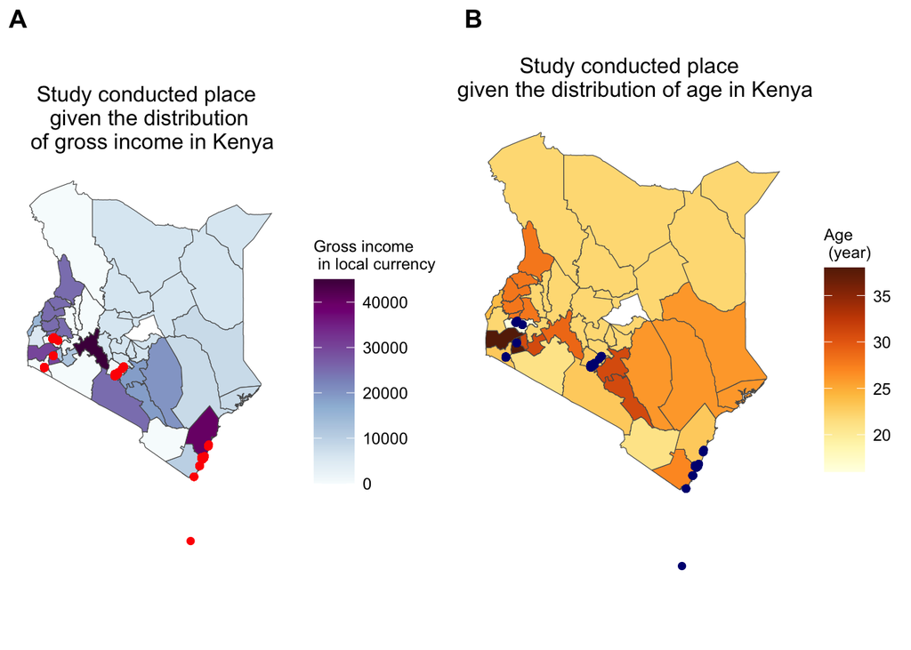

```r
library(tigris)
library(ggplot2)
library(sf)
library(maptools)
library(raster)
library(plyr)
library(rgdal)
library(geodata)
library(RColorBrewer)
library(cowplot)

#Cleaning dataset for map visualization. Create a separate dataset called dfmap.
dfmap<-df503%>%
    dplyr::select(event_name,longitude,latitude, agree_prep,county,gross_income, age, sex, education_level,employ_status,marriage_status)%>%
    dplyr::filter(event_name=="Baseline")%>%
    dplyr::filter(gross_income!="Unknown")%>%
    dplyr::filter(sex!="Other")%>%
    dplyr::filter(marriage_status!="")%>%
    tidyr::fill(longitude, .direction = 'down')%>%
    tidyr::fill(latitude, .direction = 'down')%>%
     mutate(age=as.numeric(age),
          agegrp=dplyr::case_when(age<25|age==25~"Young",
                                  age>25        ~"Adult",))%>%
   dplyr::filter(agree_prep!="")

dfmap2<-dfmap%>%dplyr::select(longitude,latitude, agree_prep,gross_income, age,sex, education_level,employ_status,marriage_status, agegrp)
sfmap<-st_as_sf(dfmap2, coords = c("longitude", "latitude"), crs = 4326)

Kenya<-getData("GADM", country="KE", level=0)
Kenya1<-getData("GADM", country="KE", level=1)

ke<-st_as_sf(Kenya1)

ke2<-ke%>%
  st_join( sfmap, ke,join = st_nearest_feature, left = T)

sherrie_theme <- function() {
  theme_minimal() +                                  # shorthand for white background color
  theme(axis.line = element_blank(),                 # further customization of theme components
        axis.text = element_blank(),                 # remove x and y axis text and labels
        axis.title = element_blank(),
        panel.grid = element_line(color = "white"),  # make grid lines invisible
        legend.key.size = unit(0.8, "cm"),           # increase size of legend
        legend.text = element_text(size = 9),       # increase legend text size
        legend.title = element_text(size = 9),
        plot.title = element_text(size=12, hjust = 0.5))      # increase legend title size
}
myPalette <- colorRampPalette(brewer.pal(9, "BuPu"))

#Create the first plot with distribution of gross_income
p1<-ggplot() +
  geom_sf(data = ke2, aes(fill=gross_income)) +
  geom_sf(data =sfmap, color = "red")+
  sherrie_theme()+
  ggtitle("Study conducted place \n given the distribution \n of gross income in Kenya") + # add plot title
  scale_fill_gradientn(name = "Gross income \n in local currency",      # change legend title
                    colours = myPalette(100))

#Create the first plot with distribution of age

myPalette2 <- colorRampPalette(brewer.pal(9, "YlOrBr"))
p2<-ggplot() +
  geom_sf(data = ke2, aes(fill=age)) +
  geom_sf(data =sfmap, color = "navyblue")+
  sherrie_theme()+
  ggtitle("Study conducted place \n given the distribution of age in Kenya") + # add plot title
  scale_fill_gradientn(name = "Age \n (year)",      # change legend title
                    colours = myPalette2(100))
plot_grid(p1,p2, labels="AUTO") #Put the two plots together
```

From the map plots, we can see one geographic location is out of Kenya, which should be suspected as outlier and need to check with data provider, and most sampled participants are in southern of Kenya, this will limited the generalization when we want to use the result to prdict participant in other regions of Kenya. Other than that, when eyeball these two plot, it looks like all samples are randomly across the Kenya, in other words, there is no obvious sign that all sampled participants are all from rich area or poverty area, neither for the variable of age (Second plot).

##### 2-2. Single demographic variables visualization

In addition to map the study, we also want to visualize the relationship between all demographic variables and outcome variable: agree_prep.

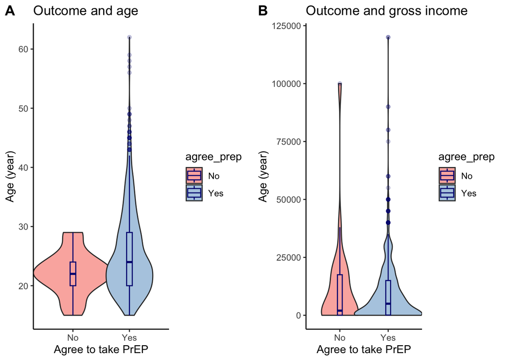

```r
#First: continuous variables

# Outcome and age
pa<-ggplot(dfmap2, aes(x=factor(agree_prep), y=age, fill=agree_prep))+
  geom_violin(width=1.4)+
  geom_boxplot(width=0.1, color="navyblue", alpha=0.2)+
  xlab("Agree to take PrEP")+
  ylab("Age (year)")+
  ggtitle("Outcome and age")+
  scale_fill_brewer(palette = "Pastel1")+
  theme_classic()

# Outcome and gross income
pb<-ggplot(dfmap2, aes(x=factor(agree_prep), y=gross_income, fill= agree_prep))+
  geom_violin(width=1.4)+
  geom_boxplot(width=0.1, color="navyblue", alpha=0.2)+
  xlab("Agree to take PrEP")+
  ylab("Age (year)")+
  ggtitle("Outcome and gross income")+
  scale_fill_brewer(palette = "Pastel1")+
  theme_classic()
plot_grid(pa,pb, labels="AUTO")
```

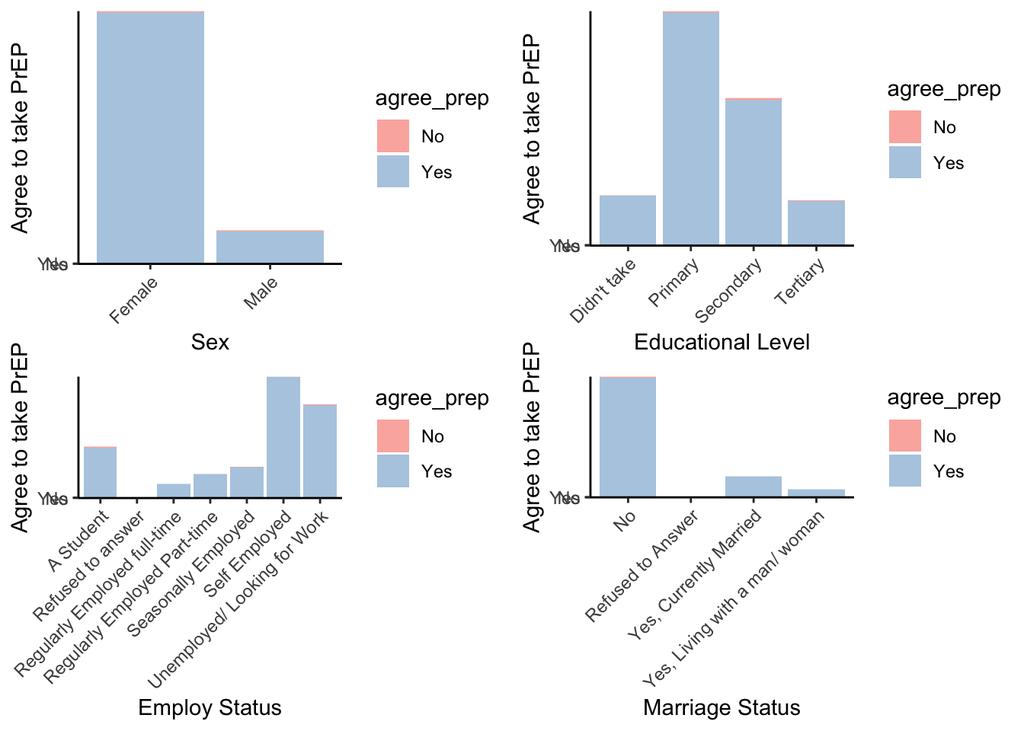

```r
#Second: Categorical variables

# Outcome and sex
library(ggmosaic)
pc<-ggplot(dfmap2,aes(x=sex,y=agree_prep,fill= agree_prep))+
  geom_col()+
  xlab("Sex")+
  ylab("Agree to take PrEP")+
  #ggtitle("Outcome and gross income")+
  scale_fill_brewer(palette = "Pastel1")+
  theme_classic()+
   theme(axis.text.x = element_text(angle = 45, vjust = 1, hjust = 1))

# Outcome and education_level
pd<-ggplot(dfmap2)+
  geom_col(aes(x=education_level, y=agree_prep, fill= agree_prep))+
  xlab("Educational Level")+
  ylab("Agree to take PrEP")+
  #ggtitle("Outcome and education level")+
  scale_fill_brewer(palette = "Pastel1")+
  theme_classic()+
   theme(axis.text.x = element_text(angle = 45, vjust = 1, hjust = 1))

# Outcome and employ_status
pe<-ggplot(dfmap2)+
  geom_col(aes(x=employ_status, y=agree_prep, fill=agree_prep))+
  xlab("Employ Status")+
  ylab("Agree to take PrEP")+
  #ggtitle("Outcome and education level")+
  scale_fill_brewer(palette = "Pastel1")+
  theme_classic()+
   theme(axis.text.x = element_text(angle = 45, vjust = 1, hjust = 1))

# Outcome and marriage_status
pf<-ggplot(dfmap2)+
  geom_col(aes(x=marriage_status, y=agree_prep, fill= agree_prep))+
  xlab("Marriage Status")+
  ylab("Agree to take PrEP")+
  #ggtitle("Outcome and education level")+
  scale_fill_brewer(palette = "Pastel1")+
  theme_classic()+
  theme(axis.text.x = element_text(angle = 45, vjust = 1, hjust = 1))

pg<-ggplot(dfmap2)+
  geom_col(aes(x=agegrp, y=agree_prep, fill= agree_prep))+
  xlab("agegrp")+
  ylab("Agree to take PrEP")+
  #ggtitle("Outcome and education level")+
  scale_fill_brewer(palette = "Pastel1")+
  theme_classic()+
  theme(axis.text.x = element_text(angle = 45, vjust = 1, hjust = 1))

plot_grid(pc, pd, pe,pf)
```

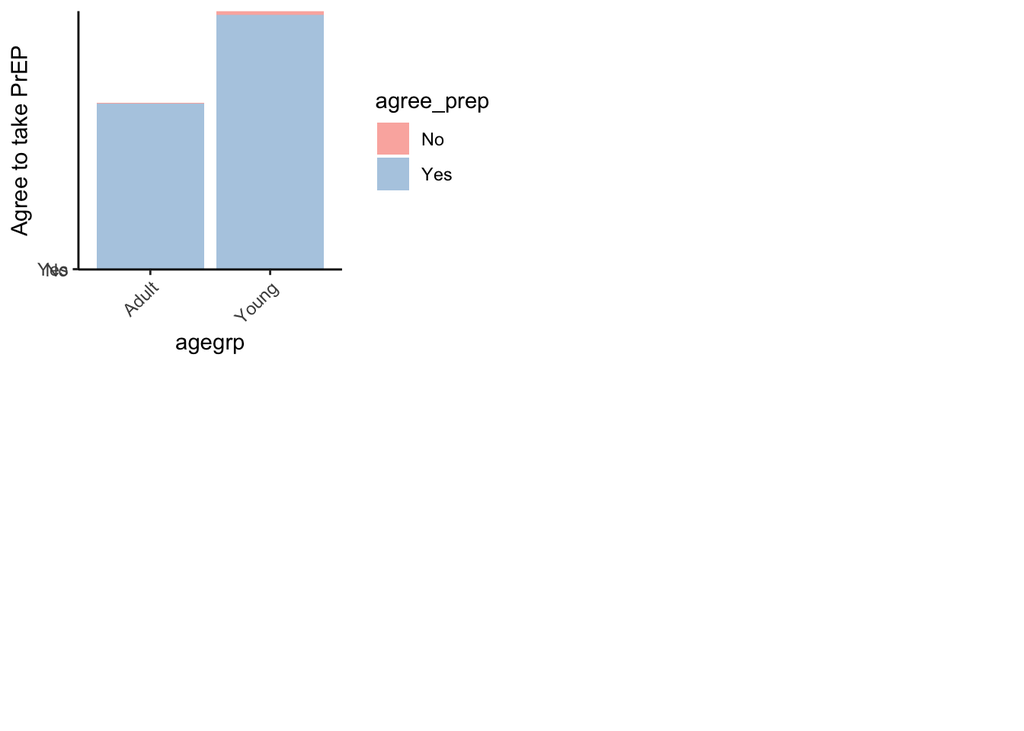

```r
plot_grid(pg, 2,1 )
```

From the plots, we can tell the distribution for each demographic variable between “Yes” and “No”group. However, we need to more specific information to see whether those varied distributions/frequencies have significant different given $\alpha$=0.05.To get that table we use gtsummary to generate table 1 in next step.

##### 2-3. Create Table 1: Demographic description of study

```r
library(gtsummary)
library(tidyverse)
dfmap%>%
  dplyr::select(agree_prep,gross_income, age,agegrp,sex, education_level,employ_status,marriage_status)%>% #select and adjust variable's display order
  dplyr::mutate(age=as.numeric(age))%>%
  gtsummary::tbl_summary(
    by=agree_prep,
      statistic = list(all_continuous() ~ "{mean} ({sd})",
                       all_categorical() ~ "{n} / {N} ({p}%)"),
    label=list(age="Age",sex="Sex", gross_income="Gross income", education_level="Education",employ_status="Employee",marriage_status="Marriage")
  )%>%
  add_p()%>%
  add_overall()%>%
  modify_header(label ~ "**Variable**")%>%
  modify_spanning_header(c("stat_1", "stat_2") ~ "**Whether agree to take PrEP**")%>%
  modify_caption("**Table 1. Demographic description of study**") %>%
  italicize_labels()%>%
  bold_labels()
```

**Table 1. Demographic description of study**

| **Variable** | **Overall**, N = 1,128<sup>1</sup> | **Whether agree to take PrEP** **No**, N = 23<sup>1</sup> | **Whether agree to take PrEP** **Yes**, N = 1,105<sup>1</sup> | **p-value**<sup>2</sup> |  |
| --- | --- | --- | --- | --- | --- |
| Gross income | 9,185 (12,936) | 12,143 (21,750) | 9,124 (12,697) |  | >0.9 |
| Age | 25 (7) | 22 (4) | 25 (7) | 0.048 |  |
| agegrp |  |  |  | 0.010 |  |
| Adult | 439 / 1,128 (39%) | 3 / 23 (13%) | 436 / 1,105 (39%) |  |  |
| Young | 689 / 1,128 (61%) | 20 / 23 (87%) | 669 / 1,105 (61%) |  |  |
| Sex |  |  |  | <0.001 |  |
| Female | 993 / 1,128 (88%) | 13 / 23 (57%) | 980 / 1,105 (89%) |  |  |
| Male | 135 / 1,128 (12%) | 10 / 23 (43%) | 125 / 1,105 (11%) |  |  |
| Education |  |  |  | 0.4 |  |
| Didn't take | 118 / 1,128 (10%) | 2 / 23 (8.7%) | 116 / 1,105 (10%) |  |  |
| Primary | 553 / 1,128 (49%) | 8 / 23 (35%) | 545 / 1,105 (49%) |  |  |
| Secondary | 350 / 1,128 (31%) | 10 / 23 (43%) | 340 / 1,105 (31%) |  |  |
| Tertiary | 107 / 1,128 (9.5%) | 3 / 23 (13%) | 104 / 1,105 (9.4%) |  |  |
| Employee |  |  |  | 0.091 |  |
| A Student | 175 / 1,128 (16%) | 9 / 23 (39%) | 166 / 1,105 (15%) |  |  |
| Refused to answer | 2 / 1,128 (0.2%) | 0 / 23 (0%) | 2 / 1,105 (0.2%) |  |  |
| Regularly Employed full-time | 47 / 1,128 (4.2%) | 1 / 23 (4.3%) | 46 / 1,105 (4.2%) |  |  |
| Regularly Employed Part-time | 80 / 1,128 (7.1%) | 1 / 23 (4.3%) | 79 / 1,105 (7.1%) |  |  |
| Seasonally Employed | 104 / 1,128 (9.2%) | 2 / 23 (8.7%) | 102 / 1,105 (9.2%) |  |  |
| Self Employed | 406 / 1,128 (36%) | 4 / 23 (17%) | 402 / 1,105 (36%) |  |  |
| Unemployed/ Looking for Work | 314 / 1,128 (28%) | 6 / 23 (26%) | 308 / 1,105 (28%) |  |  |
| Marriage |  |  |  | 0.6 |  |
| No | 913 / 1,128 (81%) | 21 / 23 (91%) | 892 / 1,105 (81%) |  |  |
| Refused to Answer | 1 / 1,128 (<0.1%) | 0 / 23 (0%) | 1 / 1,105 (<0.1%) |  |  |
| Yes, Currently Married | 156 / 1,128 (14%) | 2 / 23 (8.7%) | 154 / 1,105 (14%) |  |  |
| Yes, Living with a man/ woman | 58 / 1,128 (5.1%) | 0 / 23 (0%) | 58 / 1,105 (5.2%) |  |  |

<sup>1</sup> Mean (SD); n / N (%)  
<sup>2</sup> Wilcoxon rank sum test; Pearson's Chi-squared test; Fisher's exact test

Based on the table 1, we can see most of demographic variables are not significantly different among two groups (Agree to take PrEP v.s Not agree to take PrEP). The significant different might be resulted by imbalanced participants in two groups.

#### 3.Using Machine learning method to explore variables

Because the dataset (fdat) has over 100 variables. It is impossible to manually find significant associated variable to outcome.Since the outcome is binary, we will use GLM model to detect all significant associated variables to outcome given the $\alpha$=0.05 level.

##### 3-1. Select significant associated variables by using GLM

```r
# Finding a significant associated variables by using glm model.
datsig<-fdat%>%
  tidyr::pivot_longer(cols = -c(agree_prep)) %>%
  tidyr::nest(data = -name) %>%
  mutate(mod = purrr::map(data, ~glm(agree_prep~value, data = .x, family = binomial())),
         p.value = purrr::map_dbl(mod, ~summary(.x)$coefficients[2,4])) %>%
  dplyr::filter(p.value < 0.05)%>%
  dplyr::select(Var_Name=name, `P-value`=p.value)%>%
  arrange(`P-value`)
  #mutate(No.=seq_along(name))%>%
  kableExtra::kbl(datsig, caption = "Table 2. Variables that significant associated with outcome: by GLM algorithm ")%>%
    kableExtra::kable_classic(full_width=F, html_font = "Cambria")
```

Table 2. Variables that significant associated with outcome: by GLM algorithm

| Var_Name | P-value |
| --- | --- |
| service_received_msm_risk | 0.0000000 |
| service_received_msm_hiv | 0.0000000 |
| service_received_msm_condoms | 0.0000003 |
| risk_low_known | 0.0000019 |
| identity_group_msm | 0.0000021 |
| risk_low_condoms | 0.0000023 |
| county | 0.0000114 |
| service_received_msm_peer | 0.0002400 |
| service_received_msm_pep | 0.0003049 |
| service_received_msm_sti | 0.0003391 |
| risk_medium_status | 0.0008853 |
| risk_low_other | 0.0029068 |
| inform_dec_sex_work_money | 0.0064663 |
| service_received_csw_peer | 0.0070516 |
| risk_medium_protection | 0.0100715 |
| agegrp | 0.0144401 |
| risk_low_never | 0.0289524 |
| inform_dec_sex_work_refused | 0.0289524 |
| identity_group_fsw | 0.0343294 |

```r
#Sort P-value
datsig2<-datsig%>%
  arrange(desc(`P-value`))
```

The table lists all variables that are significant associated with outcome. However, we also want to know whether the other machine learning algorithms perform better than GLM. If so, we can choose the others to predict the outcome. Here, we also used Random Forest tree and SVM as comparison.

#### 3-2. Replicate the variable selection process by using other ML models: Random forest tree and SVM.

```r
# Random forest tree: Top 19 dfgini
library(randomForest)
df.rf <- randomForest(agree_prep ~ ., data =fdat, ntree = 200, importance = TRUE)
#df.rf$importance
df.gini<-sort(df.rf$importance[,4], decreasing =T)
dfgini<-head(df.gini,19)
  kbl(dfgini, caption="Table 3. Top 19 predictors and their gini scores: by Random forest tree algorithm", digits = 3)%>%
    kable_classic(full_width=F, html_font = "Cambria")
```

Table 3. Top 19 predictors and their gini scores: by Random forest tree algorithm

|  | x |
| --- | --- |
| decline_adhere | 7.777 |
| decline_other | 6.142 |
| decline_risk | 4.815 |
| decline_family | 3.911 |
| decline_decrease | 2.059 |
| fac_name | 1.495 |
| decline_test | 1.186 |
| county | 1.139 |
| service_received_msm_risk | 0.797 |
| risk_low_known | 0.729 |
| decline_return | 0.576 |
| risk_low_condoms | 0.565 |
| service_received_msm_condoms | 0.512 |
| risk_medium_status | 0.477 |
| risk_low_other | 0.447 |
| sexual_activity_form_complete | 0.416 |
| service_received_msm_hiv | 0.410 |
| service_received_msm_pep | 0.387 |
| current_contra_none | 0.361 |

#### 3-3. Satistic summary of RF and SVM

```r
#Random forest tree
df.rf <- randomForest(agree_prep ~ ., data =fdat, ntree = 200, importance = TRUE)
df.rf
```

```
##
## Call:
##  randomForest(formula = agree_prep ~ ., data = fdat, ntree = 200,      importance = TRUE)
##                Type of random forest: classification
##                      Number of trees: 200
## No. of variables tried at each split: 10
##
##         OOB estimate of  error rate: 1.15%
## Confusion matrix:
##     No  Yes class.error
## No  11   13   0.5416667
## Yes  0 1108   0.0000000
```

```r
# SVM
library(e1071)
fdat.svm <- svm(agree_prep ~ ., data = fdat, scale = TRUE, kernel ="radial")
svm.pred <- fitted(fdat.svm)
table(fdat$agree_prep, svm.pred)
```

```
##      svm.pred
##         No  Yes
##   No     0   24
##   Yes    0 1108
```

#### 3-4. Create the significant associated variable list based on Random forest and GLM model

```r
# Present the two selected results:
kbl(cbind(dfgini, datsig),caption="List 1.  Comparison of top-ranked significant varaibles by two algorithms", digits = 3)%>%
    add_header_above(c("Random Forest Model"= 2, "GLM Model" = 2))%>%
   kable_classic(full_width=F, html_font = "Cambria")
```

List 1. Comparison of top-ranked significant varaibles by two algorithms

| Random Forest Model | Random Forest Model dfgini | GLM Model Var_Name | GLM Model P-value |
| --- | --- | --- | --- |
| decline_adhere | 7.777 | service_received_msm_risk | 0.000 |
| decline_other | 6.142 | service_received_msm_hiv | 0.000 |
| decline_risk | 4.815 | service_received_msm_condoms | 0.000 |
| decline_family | 3.911 | risk_low_known | 0.000 |
| decline_decrease | 2.059 | identity_group_msm | 0.000 |
| fac_name | 1.495 | risk_low_condoms | 0.000 |
| decline_test | 1.186 | county | 0.000 |
| county | 1.139 | service_received_msm_peer | 0.000 |
| service_received_msm_risk | 0.797 | service_received_msm_pep | 0.000 |
| risk_low_known | 0.729 | service_received_msm_sti | 0.000 |
| decline_return | 0.576 | risk_medium_status | 0.001 |
| risk_low_condoms | 0.565 | risk_low_other | 0.003 |
| service_received_msm_condoms | 0.512 | inform_dec_sex_work_money | 0.006 |
| risk_medium_status | 0.477 | service_received_csw_peer | 0.007 |
| risk_low_other | 0.447 | risk_medium_protection | 0.010 |
| sexual_activity_form_complete | 0.416 | agegrp | 0.014 |
| service_received_msm_hiv | 0.410 | risk_low_never | 0.029 |
| service_received_msm_pep | 0.387 | inform_dec_sex_work_refused | 0.029 |
| current_contra_none | 0.361 | identity_group_fsw | 0.034 |

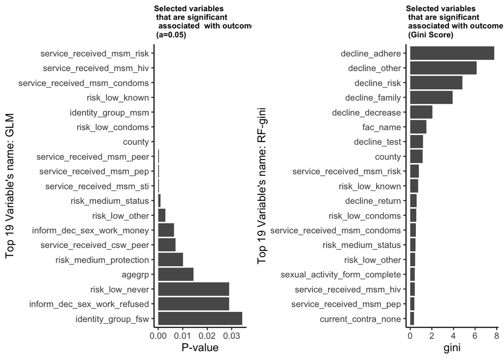

```r
#Visualized top 19 significant vars according to their p-value and Gini score

# 1) List top 19 vars based on p-value

plot1<-ggplot(datsig, aes(reorder(Var_Name,-`P-value`, sum), `P-value`)) +
            geom_bar(stat ="identity")+
            coord_flip()+
            theme_classic()+
            theme(plot.title = element_text(hjust=0, size = 8, face = "bold"))+
            xlab("Top 19 Variable's name: GLM")+
            ggtitle("Selected variables \n that are significant \n  associated  with outcome \n (a=0.05)")


# 2) List top 19 vars based on gini score

ginidf<-data.frame(name = names(df.gini), gini = df.gini)%>%
  arrange(gini)%>%
  top_n(19)
plot2<- ggplot(ginidf, aes(reorder(name, gini, sum), gini)) +
            geom_bar(stat ="identity")+
            coord_flip()+
            theme_classic()+
            theme(plot.title = element_text(hjust=0,size = 8, face = "bold"))+
            xlab("Top 19 Variable's name: RF-gini")+
            ggtitle("Selected variables \n that are significant \n associated with outcome \n (Gini Score)")

# 3) Viz two plots side by side
library(cowplot)
plot_grid(plot1, plot2)
```

The next step is visualizing performance for each model we introduced before (GLM, RF and SVM). We use K-cross validation (K=10) to see whether the assumption we made before (Extreme imbalanced dataset will impact the ML performance in a negative way) can be verified based on the results of ROC curve and AUC.Then, we will pick up the best performance model and use the top 6 variables/predictors from the list we created in previous step (see 3-4) to construct our original model.

#### 4. Model selection and evaluation

##### 4-1 Using Machine learning method to evaluate model’s performance and select a model

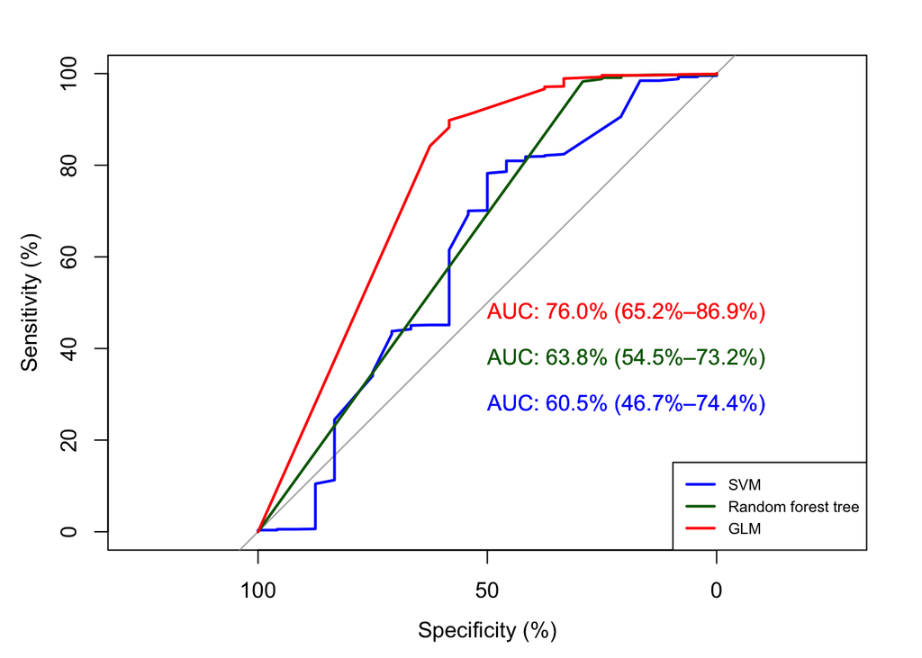

```r
N = nrow(fdat)
K = 10
set.seed(1234)
s = sample(1:K, size = N, replace = T)
pred.outputs.svm<- vector(mode = "numeric", length = N)
pred.outputs.glm<- vector(mode = "numeric", length = N)
pred.outputs.rf <- vector(mode = "numeric", length = N)
obs.outputs <- vector(mode = "numeric", length = N)
offset <- 0
for(i in 1:K){
    train <- dplyr::filter(fdat, s != i)
    test <- dplyr::filter(fdat, s == i)
    obs.outputs[1:length(s[s == i]) + offset] <- test$agree_prep

    #SVM train/test
    svm.m <- e1071::svm(agree_prep~identity_group_msm+service_received_msm_hiv+service_received_msm_risk+risk_low_known+risk_low_condoms+risk_low_never, data = train, scale = TRUE,
                 kernel = "radial", probability = TRUE)
    svm.pred.curr <- predict(svm.m, test, probability = TRUE)
    pred.outputs.svm[1:length(s[s == i]) + offset] <- attr(svm.pred.curr, "probabilities")[ , 1]

  #GLM train/test
    df.glm<-glm(agree_prep~identity_group_msm+service_received_msm_hiv+service_received_msm_risk+service_received_msm_condoms+risk_low_known+risk_low_condoms, data =fdat, family = binomial())
    glm.pred.curr <- predict(df.glm, newdata=test, type="response")
    pred.outputs.glm[1:length(s[s == i]) + offset] <- glm.pred.curr


    #RF train/test
    rf <- randomForest::randomForest(agree_prep~identity_group_msm+service_received_msm_hiv+service_received_msm_risk+risk_low_known+risk_low_condoms+risk_low_never, data = train, ntree = 100)
    rf.pred.curr <- predict(rf, newdata = test, type = "prob")
    pred.outputs.rf[1:length(s[s == i]) + offset] <- rf.pred.curr[ , 2]

    offset <- offset + length(s[s == i])
}
library(pROC)
plot.roc(obs.outputs, pred.outputs.svm, percent = TRUE,  print.auc= TRUE, print.auc.y = 30,ci = TRUE, col = "blue")
plot.roc(obs.outputs, pred.outputs.rf, percent = TRUE,  print.auc= TRUE, print.auc.y = 40,ci = TRUE, col = "darkgreen", add = TRUE)
plot.roc(obs.outputs, pred.outputs.glm, percent = TRUE,  print.auc= TRUE,print.auc.y = 50,ci = TRUE, col = "red", add = TRUE)
legend("bottomright", legend = c("SVM", "Random forest tree","GLM"), col = c("blue", "darkgreen","red"), lwd = 2, cex=.7)
```

The result shows that our two assumption is correct. First, the extreme imbalanced dataset indeed lead to very unsatisfied predictive performance for each model (None of them has AUC over 80%). In addition, among the three machine learning models, the SVM has the worst predictive performance, which is consistent with the statistic summary from each model (see 3-3).

##### 4-2. Create original GlM Model based on top 6 significant variables

```r
glmfdat<-glm(agree_prep~identity_group_msm+service_received_msm_hiv+service_received_msm_risk+service_received_msm_condoms+risk_low_known+risk_low_condoms, data =fdat, family = binomial())
s<-summary(glmfdat)
sdf<-as.data.frame(s$coefficients)
z<-exp(coef(glm(agree_prep~identity_group_msm+service_received_msm_hiv+service_received_msm_risk+risk_low_known+risk_low_condoms+risk_low_never, data=fdat, family = binomial())))

z<-as.data.frame(round(z,3))%>%
  dplyr::select(Exp_coeff="round(z, 3)")
  kableExtra::kbl(cbind(sdf,z), caption="Table 4. Summary of original GLM model", digits = 3)%>%
    kableExtra::kable_classic(full_width=F, html_font = "Cambria")
```

Table 4. Summary of original GLM model

|  | Estimate | Std. Error | z value | Pr(>\|z\|) | Exp_coeff |
| --- | --- | --- | --- | --- | --- |
| (Intercept) | -0.957 | 0.780 | -1.227 | 0.220 | 0.013 |
| identity_group_msmUnchecked | 0.429 | 1.053 | 0.407 | 0.684 | 1.654 |
| service_received_msm_hivUnchecked | 0.457 | 1.491 | 0.306 | 0.759 | 1.497 |
| service_received_msm_riskUnchecked | 1.812 | 1.196 | 1.515 | 0.130 | 5.901 |
| service_received_msm_condomsUnchecked | -0.106 | 0.926 | -0.115 | 0.909 | 4.149 |
| risk_low_knownUnchecked | 1.392 | 0.717 | 1.942 | 0.052 | 4.931 |
| risk_low_condomsUnchecked | 1.541 | 0.504 | 3.057 | 0.002 | 26.297 |

##### 4-3. Optimize predictive model

1). **Re-consider top variables generated by gini score.**

According to the Gini score result, we see several variables with prefix of “decline” have significant association with outcome. But we can see that they all have extreme imbalanced outcome number: the number for “yes” is less 10. For example, the top 1 variable: decline_adhere, the number of “yes” is only 9 out of 1132.

Whereas, the GLM consider more balanced outcome variables, the top 6 variables that we included in model are relative balanced compare to the top 6 variables in Gini score (see table 3), which all small portion of outcome (variable==“yes”) are over 25. That is why we should include top 6 variables from GLM instead of RF. Hence, for this first step, we adhere to the GLM model’s result and decide NOT to add any of new variables from Gini score result into current model.

```r
#Compare top predictor generated by gini score and GLM. Exclude critieria: remove extreme imbalanced variable from model, such as outcome is less 10 obs.
datgini6<-fdat%>%
  dplyr::select(decline_adhere,decline_other,decline_risk,decline_family,decline_decrease,decline_test)
datgini6%>%
  tbl_summary()%>%
   modify_header(label ~ "**Variable**") %>%
   modify_caption("**Top 6 significant associated vars based on Gini score**")
```

**Top 6 significant associated vars based on Gini score**

| **Variable** | **N = 1,132**<sup>1</sup> |
| --- | --- |
| decline_adhere |  |
| Checked | 9 (0.8%) |
| Unchecked | 1,123 (99%) |
| decline_other |  |
| Checked | 6 (0.5%) |
| Unchecked | 1,126 (99%) |
| decline_risk |  |
| Checked | 7 (0.6%) |
| Unchecked | 1,125 (99%) |
| decline_family |  |
| Checked | 5 (0.4%) |
| Unchecked | 1,127 (100%) |
| decline_decrease |  |
| Checked | 3 (0.3%) |
| Unchecked | 1,129 (100%) |
| decline_test |  |
| Checked | 2 (0.2%) |
| Unchecked | 1,130 (100%) |

<sup>1</sup> n (%)

```r
datglm<-fdat%>%
  dplyr::select(service_received_msm_risk,service_received_msm_hiv,service_received_msm_condoms,risk_low_known,identity_group_msm,risk_low_condoms)
datglm%>%
    tbl_summary()%>%
     modify_header(label ~ "**Variable**") %>%
     modify_caption("**Top 6 significant associated vars based on GLM**")
```

**Top 6 significant associated vars based on GLM**

| **Variable** | **N = 1,132**<sup>1</sup> |
| --- | --- |
| service_received_msm_risk |  |
| Checked | 32 (2.8%) |
| Unchecked | 1,100 (97%) |
| service_received_msm_hiv |  |
| Checked | 55 (4.9%) |
| Unchecked | 1,077 (95%) |
| service_received_msm_condoms |  |
| Checked | 32 (2.8%) |
| Unchecked | 1,100 (97%) |
| risk_low_known |  |
| Checked | 26 (2.3%) |
| Unchecked | 1,106 (98%) |
| identity_group_msm |  |
| Checked | 105 (9.3%) |
| Unchecked | 1,027 (91%) |
| risk_low_condoms |  |
| Checked | 87 (7.7%) |
| Unchecked | 1,045 (92%) |

<sup>1</sup> n (%)

2). **Using DAG conception to add demographic variables.**  
According to the demographic (table 1 result), we found that only sex and age group (agegrp) have a statistical significant association with outcome. Even though the directed acyclic graph (DAG) has limited implication for cross-sectional type dataset since it does not refelct temporal realtionship between exposure and outcome,we still want to borrow this conception to see which one or whether both of them should be included into the model if these variables affect both predictors and outcome.

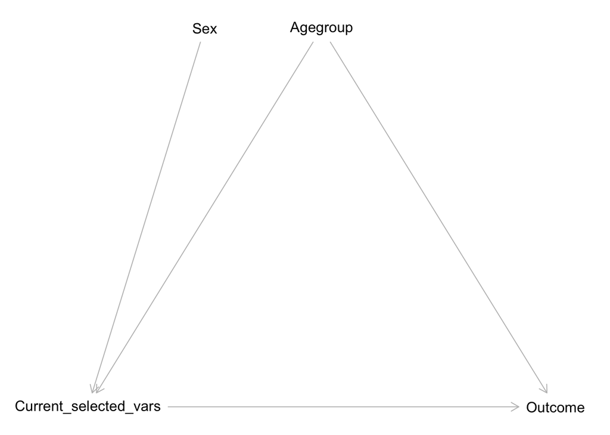

```r
library(dagitty)
library(lavaan)
g <- dagitty('dag {
    Current_selected_vars [pos="0,1"]
    Outcome  [pos="2,1"]
    Sex      [pos="0.5,0"]
    Agegroup [pos="1,0"]

    Current_selected_vars-> Outcome
    Current_selected_vars <- Agegroup-> Outcome
    Agegroup-> Outcome
    Current_selected_vars<-Sex
}')
plot(g)
```

According to the DAG, we can see that agegroup should be included into the model because it affects both current selected vars and outcome given the background knowledge. However, even though the sex shows statistical different in table 1, we do not need to include it because the sex may affect all current selected variables, however, it does not affect the outcome (decision of taking PrEP). In other words, there is no evidence that the women has significant different willingness to take PrEP compared to men or vice versa.

3). **Collinearity checking before and after optimize model**

```r
glmfdat2<-glm(agree_prep~ service_received_msm_risk+risk_low_known+risk_low_condoms+risk_low_never+agegrp, data =fdat, family = binomial())
a<-car::vif(glmfdat)
kableExtra::kable (a, caption="Table 5. VIF for variables in original GLM model", digits = 3)%>%
     column_spec(2, bold = T) %>%
     row_spec(1:4, bold = T, color = "black", background = "#d78d1e")%>%
     kableExtra::kable_classic(full_width=F, html_font = "Cambria")
```

Table 5. VIF for variables in original GLM model

|  | x |
| --- | --- |
| identity_group_msm | 4.891 |
| service_received_msm_hiv | 8.945 |
| service_received_msm_risk | 5.095 |
| service_received_msm_condoms | 2.526 |
| risk_low_known | 1.113 |
| risk_low_condoms | 1.062 |

```r
b<-car::vif(glmfdat2)
kableExtra::kable (b,caption="Table 6. VIF for variables in optimized GLM model", digits = 3)%>%
    column_spec(2, bold = T, color = "black", background = "#afd71e")%>%
    kableExtra::kable_classic(full_width=F, html_font = "Cambria")
```

Table 6. VIF for variables in optimized GLM model

|  | x |
| --- | --- |
| service_received_msm_risk | 1.074 |
| risk_low_known | 1.106 |
| risk_low_condoms | 1.083 |
| risk_low_never | 1.033 |
| agegrp | 1.027 |

In this process, we found the variable “identity_group_msm”, “service_recived_msm_hiv”, “service_received_msm_risk” have a high collinearity issue: their VIFs are close or higher than 5. So we should adjust them by removing some of these variables to eliminate the collinearity. Based on background knowledge, MSM received service usually contains HIV prevention service, so we remove the variable of “service_received_msm_hiv”, similarly reason, we should remove “identity_group_msm”.

[output not shown]

##### 4-4. Create optimized GLM model

```r
  glmfdat2<-glm(agree_prep~ service_received_msm_risk+risk_low_known+risk_low_condoms+risk_low_never+agegrp, data =fdat, family = binomial())
  s2<-summary( glmfdat2)
  sdf2<-as.data.frame(s2$coefficients)
  z2<-exp(coef(glm(agree_prep~service_received_msm_risk+risk_low_known+risk_low_condoms+risk_low_never+agegrp, data=fdat, family = binomial())))
  z2<-as.data.frame(round(z2,3))%>%
  dplyr::select(Exp_coeff="round(z2, 3)")
  kableExtra::kbl(cbind(sdf2,z2), caption="Table 7. Summary of optimized GLM model", digits = 3)%>%
    kableExtra::kable_classic(full_width=F, html_font = "Cambria")
```

Table 7. Summary of optimized GLM model

|  | Estimate | Std. Error | z value | Pr(>\|z\|) | Exp_coeff |
| --- | --- | --- | --- | --- | --- |
| (Intercept) | -2.671 | 1.545 | -1.729 | 0.084 | 0.069 |
| service_received_msm_riskUnchecked | 2.530 | 0.560 | 4.521 | 0.000 | 12.556 |
| risk_low_knownUnchecked | 1.188 | 0.713 | 1.666 | 0.096 | 3.281 |
| risk_low_condomsUnchecked | 1.816 | 0.518 | 3.507 | 0.000 | 6.150 |
| risk_low_neverUnchecked | 2.860 | 1.160 | 2.464 | 0.014 | 17.453 |
| agegrpYoung | -1.477 | 0.662 | -2.231 | 0.026 | 0.228 |

##### 4-5. Create the summary Table for optimized GLM model

```r
glmfdat2%>%
  tbl_regression(exponentiate=T,
                 label=list(service_received_msm_risk="Whether received MSM risk education service",
                            risk_low_known="Have known HIV status of all sex partner(s)",
                            risk_low_condoms="I consistently use condoms",
                            risk_low_never~"Never had sex",
                            agegrp="Age group"))%>%
  modify_table_body(~.x %>%
      mutate(label  = ifelse(label == "Checked", "Yes",
                             ifelse(label =="Unchecked", "No",label))))%>%
  bold_p()%>%
  modify_header(label ~ "**Variable**")%>%
  modify_caption("**Table 8. Statistics of optimized model**") %>%
  italicize_labels()%>%
  bold_labels()
```

**Table 8. Statistics of optimized model**

| **Variable** | **OR**<sup>1</sup> | **95% CI**<sup>1</sup> | **p-value** |
| --- | --- | --- | --- |
| Whether received MSM risk education service |  |  |  |
| Yes | — | — |  |
| No | 12.6 | 3.96, 36.4 | <0.001 |
| Have known HIV status of all sex partner(s) |  |  |  |
| Yes | — | — |  |
| No | 3.28 | 0.72, 12.1 | 0.10 |
| I consistently use condoms |  |  |  |
| Yes | — | — |  |
| No | 6.15 | 2.11, 16.5 | <0.001 |
| Never had sex |  |  |  |
| Yes | — | — |  |
| No | 17.5 | 0.85, 131 | 0.014 |
| Age group |  |  |  |
| Adult | — | — |  |
| Young | 0.23 | 0.05, 0.73 | 0.026 |

<sup>1</sup> OR = Odds Ratio, CI = Confidence Interval

```r
#create visulaized coef table for optimized GLM model
coef_table <- data.frame(
  Variables = c("Whether received MSM risk education service (ref=yes)", "I consistently use condoms (ref=yes)", "Never had sex (ref=yes)", "Age group (ref=Adult)"),
  Coefficients = c(12.6, 6.15, 17.5,0.23),
  Conf.Lower = c(3.96, 2.11, 0.85,0.05),
  Conf.Higher = c(36.4, 16.5, 131,0.73)
)

data.frame(
  Variable = coef_table$Variables,
  Visualization = ""
) %>%
  kableExtra::kbl(booktabs = T, caption="Figure 2. Coefficient for siginificant predictors from optimized GLM model")%>%
  kableExtra::kable_classic(full_width=F, html_font = "Cambria")%>%
  column_spec(2, image = spec_pointrange(
    x = coef_table$Coefficients,
    xmin = coef_table$Conf.Lower,
    xmax = coef_table$Conf.Higher,
    vline = 1)
    )
```

Figure 2. Coefficient for siginificant predictors from optimized GLM model

[output not shown]

#### 4-6. Compare two models’performance

The last step for this project is evaluating the performance of optimized model. By comparing to original model, which was only selected the top 6 variables (overlapped with Gini Score result) from GLM result, we use ROC curve and AUC value to see whether the optimized model improves the predictive performance.

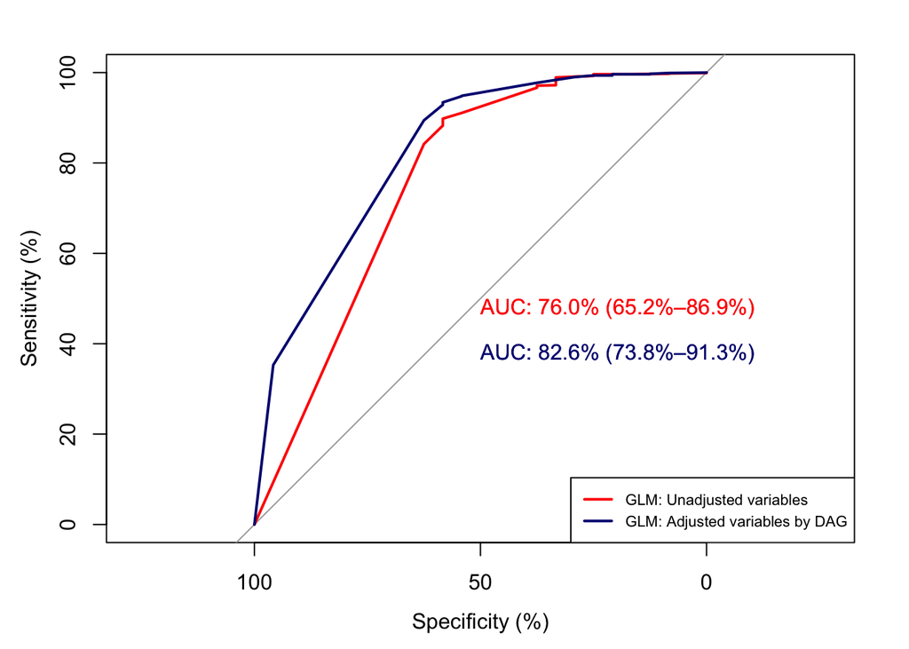

```r
N = nrow(fdat)
K = 10
set.seed(1234)
s = sample(1:K, size = N, replace = T)
pred.outputs.glm<- vector(mode = "numeric", length = N)
pred.outputs.glm2<- vector(mode = "numeric", length = N)
obs.outputs <- vector(mode = "numeric", length = N)
offset <- 0
for(i in 1:K){
    train <- dplyr::filter(fdat, s != i)
    test <- dplyr::filter(fdat, s == i)
    obs.outputs[1:length(s[s == i]) + offset] <- test$agree_prep


  #GLM train/test: First model with top 6 significant predictors in GLM model
    df.glm<-glm(agree_prep~identity_group_msm+service_received_msm_hiv+service_received_msm_risk+service_received_msm_condoms+risk_low_known+risk_low_condoms, data =fdat, family = binomial())
    glm.pred.curr <- predict(df.glm, newdata=test, type="response")
    pred.outputs.glm[1:length(s[s == i]) + offset] <- glm.pred.curr

  #GLM train/test: Second model with adjusted variables based on causal inferential theory
        df.glm2<-glm(agree_prep~service_received_msm_risk+risk_low_known+risk_low_condoms+risk_low_never+agegrp, data =fdat, family = binomial())
    glm.pred.curr2 <- predict(df.glm2, newdata=test, type="response")
    pred.outputs.glm2[1:length(s[s == i]) + offset] <- glm.pred.curr2

   offset <- offset + length(s[s == i])
}
library(pROC)
plot.roc(obs.outputs, pred.outputs.glm, percent = TRUE,  print.auc= TRUE, ci = TRUE, col = "red")
plot.roc(obs.outputs, pred.outputs.glm2, percent = TRUE, print.auc = TRUE, print.auc.y = 40,ci = TRUE, col = "navyblue", add = TRUE)
legend("bottomright", legend = c("GLM: Unadjusted variables","GLM: Adjusted variables by DAG"), col = c("red","navyblue"), lwd =2, cex=.7)
```

From the plot, we can see that the optimized the model increases the model’s performance.The AUC value is increased from 76% to 82.6%. This means that adding variable of age group helps to improve the models performance.

### Results

To interpret this result, we can say that the people who are MSM and have not received the risk education show stronger willingness to take PrEP, this result is inconsistent with previous finding, the further research should be carried to explore the reason. Other than that, the people who are older, have had sex before, and who do not consistently use condom are more likely to consider taking PrEP. Those findings are consistent with previous studies.

The GLM and top 6 significant predictors are used as original predictive model, the AUC value and ROC result shows it only has relative good performance (AUC is about 76.0%). After optimization, the optimized GLM model shows that optimization improves the model’s performance. Compare to original GLM model, the AUC value is increased to 82.6%.

### Discussion

1. **Unbalanced number of outcome**  
   Given the fact that this project used the imbalanced data, it proves that machine learning models usually cannot perfectly handle that. Specifically, imbalanced dataset here means that a classification data set with skewed class proportions. According to the previous study, machine learning models will encounter a problem for such type of dataset because when it trains on imbalanced datasets, it often have poor results when they have to generalize (predict a class or classify unseen observations). Moreover, some models will be more susceptible to unbalanced data than others despite of the chosen algorithm.[6] This has been proved in this project as we found in model selection section. To make this result more meaningful in practice, further some advanced methods such as random oversampling should be introduced to fix it.[7] To fix this type of dataset in practice, the advanced method such as random oversampling should be considered.In addition, since the weight in different outcome groups is different, it could be better to evaluate model by using F1 score and AUPRC.
2. **Completed case**  
   This study used a completed dataset to analyze, which may cause biases since the missing values may not lose randomly. In practice, we should consider to adopt the imputation package in R to fix missing value issue if the missing proportion is under the certain percentage, say less than 30%. Moreover, it also shows the importance for researchers about keeping high quality of dataset when they design and collect the data.[8][9]

### Reference

[1]Donnell, D., Baeten, J. M., Bumpus, N. N., Brantley, J., Bangsberg, D. R., Haberer, J. E., … & Celum, C. (2014). HIV protective efficacy and correlates of tenofovir blood concentrations in a clinical trial of PrEP for HIV prevention. Journal of acquired immune deficiency syndromes (1999), 66(3), 340.  
[2]Shrestha, R., & Copenhaver, M. (2018). Exploring the use of pre-exposure prophylaxis (PrEP) for HIV prevention among high-risk people who use drugs in treatment. Frontiers in public health, 6, 195.  
[3]Mahesh, B. (2020). Machine learning algorithms-a review. International Journal of Science and Research (IJSR).[Internet], 9, 381-386.  
[4]Singh, A., Thakur, N., & Sharma, A. (2016, March). A review of supervised machine learning algorithms. In 2016 3rd International Conference on Computing for Sustainable Global Development (INDIACom) (pp. 1310-1315). Ieee.  
[5]Ayodele, T. O. (2010). Types of machine learning algorithms. New advances in machine learning, 3, 19-48.  
[6] Cieslak, D. A., & Chawla, N. V. (2008, September). Learning decision trees for unbalanced data. In Joint European Conference on Machine Learning and Knowledge Discovery in Databases (pp. 241-256). Springer, Berlin, Heidelberg.  
[7] Viloria, A., Lezama, O. B. P., & Mercado-Caruzo, N. (2020). Unbalanced data processing using oversampling: Machine learning. Procedia Computer Science, 175, 108-113.  
[8]Gorelick, M. H. (2006). Bias arising from missing data in predictive models. Journal of clinical epidemiology, 59(10), 1115-1123.  
[9]White, I. R., & Carlin, J. B. (2010). Bias and efficiency of multiple imputation compared with complete‐case analysis for missing covariate values. Statistics in medicine, 29(28), 2920-2931.